# PII: 0149-2063(95)90045-4

Converted from PDF `Martin-EmployeeInvolvementDownsizing-1995-JOM.pdf` · 12 pages · anchors: page `#pN`, block `#pN-bK`

Page 1

Journal of Management

1995, Vol. 21, No. 5, 879-890

### *The Influence of Employee Involvement Program Membership During Downsizing:*

### *Attitudes Toward the Employer and the Union*

Christopher L. Martin *Louisiana State University* *in Shreveport*

Charles **K.** Parsons *Georgia* *Institute of Technology*

Nathan Bennett *Louisiana State University at Baton Rouge*

*This study investigates the influence of employee involvement (EI) program membership on attitudes towards an organization, its management, and the union during organizational downsizing. Respondents were 147 union members who had been notified of their discharge from a large manufacturer. EI membership had signtjicant effects on worker commitment to the organization, attitudes towards management, perceivedfairness and attributions of blame, but not on attitudes toward the union. However, EImembers didplace somewhat greater blame for the layoff on the union.*

Responding to intense competitive pressures, many organizations have adopted team-based employee involvement (EI) programs (e.g., Quality Circles, Total Quality Management, Quality of Work Life Committees), with the belief that such programs will lead to increased productivity and cost reductions (Blinder, 1989; Lawler & Mohrman, 1985, 1987; Meyer & Scott, 1985). Although such programs have been directed toward solving job-related quality problems and improving methods of production, research has linked participation in EI programs to a variety of other positive employee behaviors and attitudes. For example, participation has been tied to increased levels of satisfaction and organizational commitment (Cotton, Vollrath, Froggatt, Lengnick-Hall & Jennings, 1988; Griffin & Bateman, 1986) and has been found to facilitate communication within groups and commitment to organizational goals (Locke & Schweiger, 1979). Such programs have also been found to lead to improved working conditions, and to provide greater opportunities for employee input and self-development (Lawler, 1986).

Direct all correspondence to: Christopher L. Martin, Louisiana State University, Department of Management and Marketing, Shreveport, LA 71115. e-mail <SHCMAR @ LSUVM.sncc.LSU.edu>.

#### **Copyright @ 1995 by JAI Press Inc. 0149-2063**

**879**

Page 2

880 MARTIN, PARSONS, AND BENNETT

In recent empirical evaluations of these programs, the focus has been on organizational or employee outcomes such as productivity, absenteeism, quality of work life, organizational and union commitment, and job satisfaction (Griffin, 1988; Marks, Mirvis, Hackett & Grady, 1986; Mellor, 1992). A possible additional benefit of EI program membership which has yet to be investigated concerns the role that membership may have as a source of support during threatening organizational changes. Marks et al. (1986) found that EI program members, who were exposed to the same negative organizational changes as non-members, suffered less of a drop in quality-of-work-life attitudes. An indirect asset of EI programs may be that the teams provided a forum in which employees could receive clarification regarding changes, as well as distinguish facts from rumors. Marks et al. (1986) suggest that membership may therefore have been a source of informational support that buffered members’ negative attitudinal response to potentially threatening changes. The purpose of this paper is to directly test this proposition in a sample of employees scheduled for a layoff. The focal research question is then how specifically does EI program membership affect the work attitudes of employees who learn they will soon be permanently laid off!

As corporations downsize, the possibility of layoff is perhaps the most ominous change facing workers. The downsizing literature (Cameron, Whetten & Kim, 1987; Wheeler, Gray, Giacobbe & Quick, 1990) suggests that employees’ work behaviors and attitudes about employers erode once they are notified of impending layoffs. Past research has focused primarily on the reactions of layoff survivors (i.e., those who remain employed with the downsized organization, Brockner & Greenberg, 1990). However, as a consequence of the extended warning provisions of the Worker Adjustment and Retraining Notification (WARN) Act of 1988, individuals remain in their jobs and are expected to perform their tasks and duties for a significant amount of time after learning they will be laid off. Research has found decreases in employee morale, loyalty, commitment, innovation, and participation are commonly observed after layoff notification (Leana & Feldman, 1992). While these victim reactions are costly to the organization, there is also the likelihood that these victims, now disgruntled, will also undesirably intluence the reactions of layoff survivors (Brockner, 1988). For these two reasons, understanding the job-related attitudes and behaviors of layoff victims after notification is critical (Bies, Martin & Brockner, 1993; Martin & Bies, 1991).

Research has demonstrated that perceptions of the fairness of a layoff have an important impact on survivors’ continued attitudes toward the employer (Bies, Martin & Brockner, 1993; Brockner, 1988; Brockner & Greenberg, 1990). In all, research suggests that “appearing fair” prevents an erosion of employee morale and commitment. Judgments of fair treatment during a layoff are not simply based on distributive fairness concerns of whether or not a particular employee received a desired outcome (i.e., did they keep their job). Fairness judgments greatly depend on both the procedures used (cf. Leventhal, 1980;

Thibaut & Walker, 1975) and the interpersonal treatment afforded individuals during layoff implementation (cf. Bies & Moag, 1986; Tyler & Bies, 1990). For

JOURNAL OF MANAGEMENT, VOL. 21, NO. 5, 1995

Page 3

EI AND DOWNSIZING 881

example, did management offer an adequate explanation of the reasons for the layoff? An emphasis on interpersonal communi&ation during the implementa- tion of organizations procedures is the gist of interactional justice (Bies & Moag, 1986).

Consistent with other research on communication and its role in developing perceptions of fairness (Bies, 1987; Folger & Martin, 1986), Bies et al. (1993) found employee perceptions of fairness were enhanced when “bad news” such as layoff not~cation was delivered with adequate, open, and t~thful communication. Indeed, Bies et al. (1993) determined that layoff victims focused more on the interpersonal treatment they received during layoff implementation than on distributive issues or the structural characteristics of procedures, such as voice and appeal mechanisms. Since such communication is likely facilitated through EI programs (Fitzgerald & Murphy, 1982), membership may ameliorate workers’ negative reactions to the layoff. Based on these points, we hypothesize:

**HlA: *After notification of their 1ayofJ victims who have been members of*** EI *programs will report higher levels of fairness of the layoff process tharz eon-members.*

**HlB: *After notl~cation of their layoff; victims who have been members of*** *EI* *programs will report higher levels of organizational commitment than non-members.*

Leana and Feldman (1992) have analyzed attributional processes layoff victims use to affix blame in an layoff context. Leana and Feldman (1988) propose that victims of large scale work force reductions or plant closings will attribute job loss to factors outside of their control rather than to themselves, because in such cases, incompetence is not implied by termination. Indeed, frustrations and anxieties of organizational decline are frequently blamed on management, because of its failure to protect employees from pain or to arrest decline (Krantz, 1985). Alternatively, the emphasis on indi~dualism in our culture has been thought to be a potential impetus for the unemployed to blame themselves (Newman, 1988). However, in their research, Leana and Feldman (1992) found that individuals engaged in little self-blame, with most blame targeted at management incompetence. Since EI programs include employees in the management process and expose them to the circumstances of the decline, they could be expected to lead employees to place less blame for the layoff on management. Thus, we hypothesize:

**H2A: *After notification of their layoff; victims who have been members of*** Ef *programs will report more pro-management attitudes than non-members.*

*H2B: After notljkation of their layoff; victims who have been members of EI programs will place less blame for the layoff on management than will non-members.*

JOURNAL OF MANAG~ME~, VOL. 21, NO. $1995

Page 4

882 MARTIN, PARSONS, AND BENNETT

Because of the equivocality of the literature addressing EI membership and attitudes towards unions, we do not formulate a specific hypothesis. It is important, however, to learn more about whether EI programs may increase blame attributed to a union during a layoff. At least one study has found that lower levels of union commitment were reported by members who believed management accounts blaming the union for layoffs (Mellor, 1992). Therefore, we explore the relationship between EI membership and layoff victims’attitudes concerning the union.

#### **Method**

*Research Site*

The research site was a large (N=2,400), unionized manufacturing facility located in an “open shop" state. The plant was part of a multinational corporation with over 280,000 employees worldwide. Each of the corporation’s man~actu~ng plants bid against one another to retain their current product line and win new product contracts. To compete profitably in the global marketplace, all of the corporation’s U.S. facilities were forced to cut costs, delivery times, and employees, while maintaining quality. In 1986, the EI concept was introduced by plant management as a means to aggressively manage costs and quality, and as an evolutionary step toward self-managing work teams.

Over the next four years, top management randomly selected teams throughout the plant for inclusion in the EI program. By the end of the fourth year, over 55% of the total non-management work force were EI program members. Teams met for one hour each week and were led by team supervisors. Trained facilitators coordinated the overall program and provided support for the teams. This included in-depth training as to the process and phiIosophy of EI, selecting group projects, and applying productivity and quality improvement tools.

As specified in the organization’s EI material, the agenda for teams was: to enhance and open employee communication; set and meet challenging goals; meet commitments to customers as well as in individual and group performance; activate employee pa~icipation~ empowe~ent; move decision making and accountability to appropriate levels; reduce product costs; develop teamwork with internal and external partners; and continuously improve both people and operations.

JOURNAL OF MANAGEMENT, VOL. 21, NO. 5, I995

Page 5

EI AND DOWNSIZING 883

Three months prior to our study, a sample (N=1,340) of employees was surveyed by plant management, giving employees an opportunity to voluntarily provide their assessment of the EI process. Responses were received from 1,032 employees (77% response rate); approximately sixty percent of the respondents were EI members. On virtually all goals associated with the EI program, large numbers of employees felt there had been significant progress since the process was launched (e.g., responded “greatly” or “somewhat” improved to items addressing housekeeping, 9 1 Ye; product throughput time, 83%; customer satisfaction, 77%; design for manufacturing, 75%; setting objectives and following through, 70%). Least improved was union/ management relations (37% answering “greatly” or “somewhat”). Although no exact figure was available in terms of cost savings generated by the EI program, two years prior to this survey the facility was named one of the 10 most productive facilities in the country by a leading business magazine. One month following the in- house EI survey, the corporation pulled a product line from the plant site and awarded it to an overseas manufacturing facility. This resulted in the permanent layoff of 2 10 skilled trade employees. The layoff victims were informed in writing that this was to be a permanent layoff with no chance of a recall.

#### *Respondents and Procedures*

The study was conducted approximately two months after the announcement of the layoff and one month before the respondents' termination. During organizational “exit interviews”, those scheduled for layoff (N=210) were told of a university sponsored study on the victims of layoffs. Employees who wished to participate (N=147, 7095) were then escorted by the principal investigator to a conference room, where they each completed the questionnaire.

This sample provides a distinct advantage over earlier studies of EI programs. Since workers were assigned to EI teams, there is no danger of the self-selection bias present in earlier studies where workers volunteered to participate. That is, response differences between EI members and non- members are unlikely to be explained by characteristics of those who happen to volunteer to participate in EI (cf. Leana, Ahlbrandt & Murrell, 1992).

#### *Measures*

EI **program membership.** Respondents were asked on the survey “Are you a member of a quality team ?” The responses were then verified through

JOURNAL OF MANAGEMENT, VOL. 21, NO. 5, 1995

Page 6

884 MARTIN, PARSONS, AND BENNETT

organizational records, and no discrepancy was found. This variable was dummy coded (0,l) such that a “1” indicated EI membership (N=107).

**Blame.** Blame for the respondent’s layoff was assessed by means of single- item measures (“Management (The union) is to blame for this layoff”). In addition to blame attributed to management and the union, the study included an item assessing the degree to which individuals blamed themselves for the layoff (“I blame myself and others like me for the layoff”). Responses were on a 7-point scale ranging from “strongly disagree” to “strongly agree,” such that a high score reflects high blame.

JOURNAL OF MANAGEMENT, VOL. 21, NO. 5, 1995

Page 7

**EI AND DOWNSIZING 885**

#### **Results**

The following procedure was used to test the hypotheses. First, because of intercorrelations among the dependent variables (Mean r=.23), a multivariate analysis of variance (MANOVA) was conducted. Based on a significant F for that analysis (Wilks *L=* .88; *F* 8,121=2.15,p<.O5), follow-up analyses of variance (ANOVA) were performed to explore mean differences in the dependent variables based on employee EI membership status. The results of the ANOVAs are presented in Table 2.

**JOURNAL OF MANAGEMENT, VOL. 21, NO. 5, 1995**

Page 8

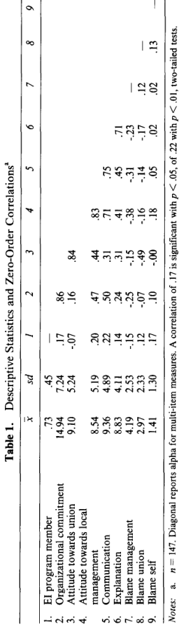

NOTE: complex table shown as an image of the PDF; the text below is a rough machine extraction and may be mis-aligned.

**extracted text (unreliable layout)**

.~. “3 **Table 1.** Descriptive Statistics and Zero-Order Correlations”

3 x *sd 1* 2 3 4 5 6 7 8 9

c! 1. EI program member .73 45

Notes: a. n = 147. Diagonal reports alpha for multi-item measures. A correlation of .I7 is significant withp < .05, of .22 withp < .Ol, two-tailed tests.

Page 9

EI AND DOWNSIZING 887

**Table 2.** Results of Analysis of Variance for EI Program Membership

and Employee Attitudes”

[output not shown]

NOTE: table converted from PDF layout to HTML text; cell boundaries are reconstructed. See PDF if exact alignment matters.

Notes: a. n = 147.

tp<.10; * p < .05; ** p < .Ol

Discussion

This study represents an initial examination of how participation in EI programs affects reactions to a layoff and victims’ feelings toward the union and management. In all, our findings point to effects of EI programs beyond those typically identified. The study suggests that EI membership does make a difference in worker responses to being discharged. Despite the fact that they faced permanent layoff, EI members reported higher levels of organizational commitment and more favorable attitudes towards management than non- members faced with the same outcome.

EI members, as compared to non-members, reported there was better communication about the layoff. These findings are consistent with those reported by Bies et al. (1993) in that poor outcomes are better received when communicated in a considerate, respectful manner. In all, interactional justice was significantly and positively associated with evaluations of management and commitment to the organization. To the extent that EI membership serves as a vehicle for affecting judgments of interactional fairness, this suggests another beneficial consequence of such programs. As noted earlier, some unions have been opposed to group-based work innovations, fearing that participation techniques may cause workers to side with management on controversial issues. Our findings suggest that this fear may be justified in that EI membership had an impact on where layoff victims

JOURNAL OF MANAGEMENT, VOL. 21, NO. 5, 1995

Page 10

888 MARTIN, PARSONS, AND BENNET-

placed blame. As compared to non-members, El members were less severe in their assignment of blame to management and more severe in their assignment of blame to the union and themselves. In conjunction with the finding that EI membership did not result in mean differences in attitudes toward the union, this suggests that EI processes affected members’ attributional processes but not their evaluation of the union. Finally, the finding that union blame was greater among employees who reported lower evaluations of interactional justice may indicate some employees felt that the union was not doing its part

to pressure management for adequate explanation.

Certain limitations to the study should be noted, to correctly frame these results and also stimulate future research on this topic. Because the data were all collected from a single plant, the findings do not necessarily generalize to other organizations. For instance, if the union had opposed the EI concept, we might have seen an entirely different set of results. Investigations of the relationships we considered in different organizational contexts is clearly warranted.

We could not address how individuals differed in regard to their degree of involvement in the EI process. Though anecdotal evidence suggests that participation was generally the norm, EI members were not necessarily committed to the EI concept, as they typically are in studies where membership is voluntary. In this plant, workers were told to, at a minimum, attend and not disrupt sessions. This acts to make our tests of EI membership conservative, in that some members may be hostile to EL As a result, it may be more difficult to demonstrate an effect for EI membership.

Regardless, future research should consider how the duration of EI involvement or amount of commitment to EI influences employees’ attitudes towards employers and unions. Of particular interest may be the role of perceived organizational support (cf. Eisenberg, Faso10 & Davis-LaMastro,

1990; Eisenberg, Huntin~on, Hutchinson & Sowa, 1986; Shore & Wayne, 1993) as a precursor to EI involvement, One consequence of perceived organizational support is thought to be the development of an “evaluation bias” that influences individuals’ judgments about employers (Eisenberg et al., 1990). Research on

JOURNAL OF MANAGEMENT, VOL. 21, NO. 5, 1995

Page 11

EI AND DOWNSIZING 889

this concept in an EI context would provide further understanding of the mechanism through which involvement affects employees’ views of employers.

Finally, these findings have some interesting implications for justice research due, in large part, to the context in which this study took place. Layoff victims are in an intriguing position with regard to justice. Their outcome, job loss, is distributively poor. Many of the structural aspects of procedural justice (e.g., voice, appeal mechanisms) are not typically available to layoff victims. In all, the only source of fairness they can likely access involves the quality of the interpersonal treatment they receive from their employer (Bies et al., 1993). Given the importance of fairness perceptions to both layoff survivors and victims, further study of interactional justice and of the role that El plays as a conduit for evidence of fair treatment is clearly warranted.

**Acknowledgment:** The authors would like to thank Kevin Mossholder and Craig Russell for their comments on this paper. Please address all correspondence to the first author.

#### **References**

Bies, R.J. (1987). The predicament of injustice: The management of moral outrage. Pp. 289-319 in B. Staw & L.L. Cummings (Eds.), *Research in organizational behavior,* Vol. *9.* Greenwich, CT: JAI Press. Bies, R.J., Martin, CL. & Brockner, J. (1993). Just laid off but still a good citizen: Only if the process is fair. *Employee Responsibilities and Rights Journal, 6: 227-238.* Bies, R.J. & Moag, J.S. (1986). Interactional justice: Communication criteria of fairness. Pp. 43-55 in Roy Lewicki (Ed.), *Research on negotiation in organizauons,* Vol. 1. Greenwich, CT: JAI Press. Blinder, A. (1989). Want to boost productivity? Try giving workers a say. Business Week, (April 17): 10. Brockner, J. (1988). The effects of work layoffs on survivors: Research theory, and practice. Pp. 213-255 in B. Staw & L.L. Cummings (Eds.), *Research in organizational behavior,* Vol. 10. Greeenwich, CT: JAI Press. Brockner, J. & Greenberg, J. (1990). The impact of layoffs on survivors: An organizational justice perspective. Pp. 45-75 in John S. Carrol (Ed.), *Ad vances in applied socialpsychology: Business settings.* Hillsdale, NJ: Erlbaum. Cameron, K.S., Whetten, D.A. & Kim, M.U. (1987). Organizational dysfunctions of decline. *Academy of Management Journal, 30: 126-138.* Cotton, J.L., Vollrath, D.A., Froggatt, K.L., Lengnick-Hall, M.L. & Jennings, K.R. (1988). Employee participation: Diverse forms and different outcomes. *Academy* of Managemenr *Review, 13: 8-22.* Eisenberg, R., Fasolo, P. & Davis-LaMastro, V. (1990). Perceived organizational support and employee diligence, commitment, and innovation, *Journal of Applied Psychology, 75: 5 l-59.* Eisenberg, R., Huntington, R., Hutchinson, S. & Sowa, D. (1986). Perceived organizational support. *Journal of Applied Psychology, 71: 500-507.* Fitzgerald, L. & Murphy, J. (1982). *Installing quality circles: A strategic approach.* San Diego. University Associates, Griffin, R.W. (1988). Consequences of quality circles in an industrial setting: A longitudinal assessment. *Academy of Managemenr Journal, 31: 338-358.* Griffin, R.W. & Bateman, T. (1986). Job satisfaction and organizational commitment. Pp. 157-188 in C.L. Cooper & I. Robertson (Eds.), *International review of industrial and organizarional psychology.* London: John Wiley & Sons. *IAM While Paper on Team Concept Programs. (1990).* International Association of Machinists and Aerospace Workers, Krantz, J. (1985). Group processes under conditions of organizational decline. *Journal of Applied Behavioral* Science, *21: 1-17.* Lawler, E.E. (1986). *High-involvement management.* San Fransisco: Jossey-Bass. Lawler, E.E. & Mohrman, S.A. (1985). Quality circles after the fad. *Harvard Business Review, 63: 65-71. ~. (1987).* Quality circles: After the honey-moon. *Organizational Dynamics, 15: 42-54.*

JOURNAL OF MANAGEMENT, VOL. 21, NO. 5, 1995

Page 12

890 MARTIN, PARSONS, AND BENNETT

Leana, C.R., Ahlbrandt, R.S. & Murrell, A.J. (1992). The effects of employee involvement programs on unionized workers’ attitudes, perceptions, and preferences in decision making. *Academy of Management Journal, 35: 861-873.* Leana, CR. & Feldman, D.C. (1988). Individual responses to job loss: Perceptions, reactions, and coping behaviors. *Journal of Management, 14: 375389. -. (1992). Coping with job loss: How individuals, organizations, and communities respond to layoffs. New* York: Lexington. Leventhal, G.S. (1980). What should be done with equity theory? Pp. 27-55 in K.J. Gergen, M.S. Greenberg & R.H. Willis (Eds.), *Socialexchange: Advances in theory and research. New* York: Plenum. Locke, E.A. & Schweiger, D.M. (1979). Participation in decision-making: One more look. Pp. 265-339 in B. Staw (Ed.), *Research in organizational behavior,* Vol. 1. Greenwich, CT, JAI Press. Marks, M.L., Mirvis, P.H., Hackett, E.J. & Grady, J.F. Jr. (1986). Employee participation in a quality circle program: Impact on quality of work life, productivity, and absenteeism. *Journal of Applied Psychology, 71: 61-69.* Mellor, S. (1992). The influence of layoff severity on postlayoff union commitment among survivors: The moderating effect of the perceived legitimacy of a layoff account. *Personnel Psychology, 45: 579- 600.* Meyer, G.W. & Scott, R.G. (1985). Quality circles: Panacea or Pandora’s Box? *Organizational Dynamics, 13: 34-50.* Newman, K.S. (1988). *Falling from grace: 7’he experience of downward mobility in the American middle class. New* York: Vintage. Nunnally, J.C. (1967). *Psychometric theory. New* York: McGraw-Hill. O’Reilly, C. III & Chatman, J. (1986). Organizational commitment and psychological attachment: The effects of compliance, identification, and internalization on personal behavior. *Journal of Applied Psychology, 71: 492499.* Perline, M.M. & Poynter, D.J. (1989). The effects of worker participation plans on union views of managerial perogatives. *Labor Law‘Journal, 40: 37-44. _* _ _ Sherer. P.D. & Morishima. M. (1989). Roads and roadblocks to dual commitment: Similar and dissimilar ‘antecedents of union and‘company commitment. *Journal of Labor Research, IO: 31 I-330.* Shore, L.M. & Wayne, S.J. (1993). Commitment and employee behavior: Comparison of affective commitment and continuance commitment with perceived organizational support. *Journalof Applied Psychology, 78: 774-780.* Thibaut, J. & Walker, L. (1975). *Proceduraljustice:* A *psychological analysis.* Hillsdale, NJ: Erlbaum. Tyler, T.R. & Bies, R.J. 1990. Beyond formal procedures: The interpersonal context of procedural justice. Pp. 77-98 in J.S. Carroll (Ed.), *Applied socialpsychology and organizational sertings.* Hillsdale, NJ: Erlbaum. Verma, A. (1989). Joint participation programs: Self-help *or* suicide for labor? *Industriul Relations, 28: 401- 410.* Wheeler, K., Gray, D., Giacobbe, J. & Quick, J. (1990). *Organizational and human resource results of corporate restructuring: Problems, pitfalls, and benefits.* Paper presented at the Academy of Management meetings, San Francisco, CA.

JOURNAL OF MANAGEMENT, VOL. 21, NO. 5, 1995